# CUSTOMER SEGMENTATION

# Correlation of Various variables with Spending

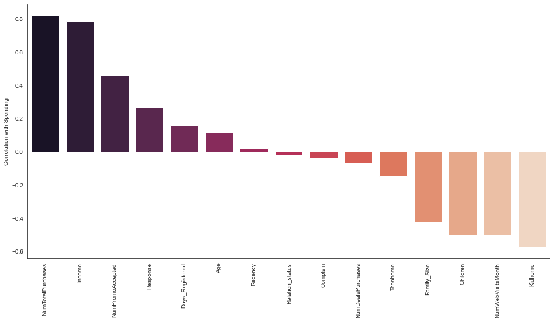

```python
fig, ax = plt.subplots(figsize=(16,8))

#ax.text(-1, 1.2, 'Correlation of Various variables with Spending', fontsize=15, fontweight='bold', color='blue')
corr_spending = pd.DataFrame(data[data.columns[~data.columns.isin(['Education','Spending'])]].corrwith(data['Spending'])).rename(columns={0:'Correlation'}).sort_values('Correlation',ascending=False)
corr_spending

sns.barplot(x=corr_spending.index, y=corr_spending['Correlation'], ax=ax, palette='rocket')
ax.set_ylabel('Correlation with Spending')

for s in ["top","right"]:
    ax.spines[s].set_visible(False)

ax.set_xticklabels(ax.get_xticklabels(), rotation=90);

plt.show()
```

```python
print(color.BOLD+color.BLUE  +"Correlation of Various variables with Spending"+ color.END)
corr_spending
```

```
Correlation of Various variables with Spending
```

|  | Correlation |
| --- | --- |
| NumTotalPurchases | 0.820687 |
| Income | 0.787799 |
| NumPromoAccepted | 0.459554 |
| Response | 0.265298 |
| Days_Registered | 0.158814 |
| Age | 0.112838 |
| Recency | 0.020433 |
| Relation_status | -0.017744 |
| Complain | -0.037058 |
| NumDealsPurchases | -0.065112 |
| Teenhome | -0.149480 |
| Family_Size | -0.422907 |
| Children | -0.498888 |
| NumWebVisitsMonth | -0.500218 |
| Kidhome | -0.573386 |

```
Total spending on Wines, Fruits, MeatProducts, FishProducts, SweetProducts, GoldProds wrt to Family_Size
```

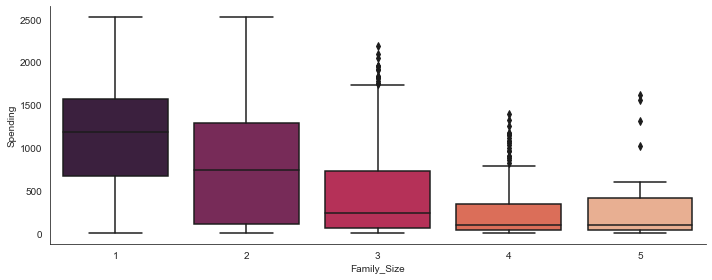

```python
print(color.BOLD+color.BLUE  +"Total spending on Wines, Fruits, MeatProducts, FishProducts, SweetProducts, GoldProds wrt to Family_Size"+ color.END)
sns.catplot(x="Family_Size", y="Spending", kind="box", data=data, height=4, aspect=2.5/1, palette='rocket');
```

```
Total spending on Wines, Fruits, MeatProducts, FishProducts, SweetProducts, GoldProds wrt to #Children
```

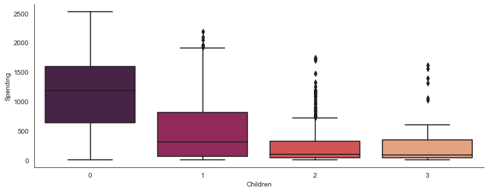

```python
print(color.BOLD+color.BLUE  +"Total spending on Wines, Fruits, MeatProducts, FishProducts, SweetProducts, GoldProds wrt to #Children"+ color.END)
sns.catplot(x="Children", y="Spending", kind="box", data=data, height=4, aspect=2.5/1, palette='rocket');
```

```
Total spending on Wines, Fruits, MeatProducts, FishProducts, SweetProducts, GoldProds wrt to NumWebVisitsMonth
```

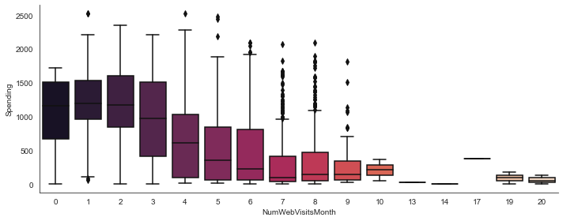

```python
print(color.BOLD+color.BLUE  +"Total spending on Wines, Fruits, MeatProducts, FishProducts, SweetProducts, GoldProds wrt to NumWebVisitsMonth"+ color.END)
sns.catplot(x="NumWebVisitsMonth", y="Spending", kind="box", data=data, height=4, aspect=2.5/1, palette='rocket');
```

*NumTotalPurchases and Income have very high positive correlation with Spending.  
*Recency and Relation_status have low correlation with Spending.  
*Larger Families, i.e families with Children or Kids, spend less on Wines, Fruits, Meat Products, Fish Products, Sweet Products, Gold Prods.  
*With the increase in the number of visits per month, total spending is decreasing.

## **Data Preprocessing**

This section if for data pre-processing to carryout clustering operations.

Following steps are applied to preprocessed the data:

1. Encoding categorical features
2. Scaling Variables using standard scaler
3. Creating a subset data frame for dimensionality reduction

# Encoding categorical Variables

Encode the categorical variable Education to binary variables.

```python
# Encode factors of education into binary creating new variables PG_Education and Grad_Education
data["PG_Education"] = np.where(data.Education=='Postgraduate', 1, 0)
data["Grad_Education"] = np.where(data.Education=='Graduate', 1, 0)
```

```python
#drop categorical variable education
data = data.drop(['Education'], axis=1)
```

# Scaling Variables using standard scaler

We will Scale all the variables in the data using a standard scaler for building the models

```python
#Scaling Variables using standard scaler
scaler = StandardScaler()
scaler.fit(data)
scaled_data = pd.DataFrame(scaler.transform(data),columns= data.columns )
```

## **Dimensionality Reduction with PCA**

Dimensionality reduction is a method reducing number of variables in a dataset. While working with large datasets, larger the number of variables, the more difficult it is to build a model with them. Additionally, some of the variables can redundant, adding noise to the model.

With this intension, we adopt dimensionality reduction techniques. Dimensionality reduction, or dimension reduction, is the transformation of data from a high-dimensional space into a low-dimensional space so that the low-dimensional representation retains some meaningful properties of the original data, ideally close to its intrinsic dimension.[(wikipedia)](https://en.wikipedia.org/wiki/Dimensionality_reduction). Dimensionality reduction can be used for noise reduction, data visualization, cluster analysis, or as an intermediate step to facilitate other analyses.

In this section we will use a Linear-technique for dimensionality reduction called Principal component analysis (PCA)

```python
# based on the number of variables, I will reduce all the variables to 4 principle components

pca = PCA(n_components=4)
pca.fit(scaled_data)
components = pd.DataFrame(pca.transform(scaled_data), columns=(['PC1','PC2','PC3','PC4']))
```

```python
components.describe().T
```

|  | count | mean | std | min | 25% | 50% | 75% | max |
| --- | --- | --- | --- | --- | --- | --- | --- | --- |
| PC1 | 2240.0 | 1.982541e-17 | 2.158664 | -5.859272 | -1.454416 | 0.273159 | 1.798085 | 6.393371 |
| PC2 | 2240.0 | 1.506731e-17 | 1.528503 | -3.830168 | -1.167739 | 0.090980 | 1.105131 | 5.501350 |
| PC3 | 2240.0 | 4.559845e-18 | 1.335365 | -2.821604 | -1.252532 | 0.320393 | 1.163306 | 2.873853 |
| PC4 | 2240.0 | 2.755732e-17 | 1.264388 | -2.901653 | -0.917062 | -0.169902 | 0.724398 | 4.970224 |

## **Clustering**

Clustering is an unsupervised machine learning technique. Through clustering a dataset is divided into clusters or groups where members belonging to same cluster have similar properties. The most common clustering algorithms are K-Means clustering, Hierarchical clustering, Density-based clustering, Model-based clustering, etc.

Steps involved in the Clustering

1. Elbow Method to determine the number of clusters to be formed
2. Applying Clustering techniques
3. Examining the clusters formed via scatter plot

# Finding K

Finding optimal number of clusters(K) very important part of this algorithm.  
A commonly used method for finding optimal K value is Elbow Method.

```
Elbow method to determine optimal number of clusters:
```

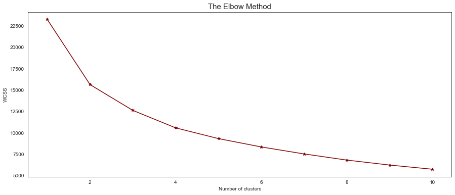

```python
fig, ax = plt.subplots(figsize=(15,6))

# Quick examination of elbow method to find numbers of clusters to make.
print(color.BOLD+color.BLUE  +'Elbow method to determine optimal number of clusters:'+ color.END)

X = components.values
wcss = []
for i in range(1, 11):
    kmeans = KMeans(n_clusters = i, init = 'k-means++', random_state = 0)
    kmeans.fit(X)
    wcss.append(kmeans.inertia_)
plt.plot(range(1, 11), wcss,color = "Maroon",marker = '*')
plt.title('The Elbow Method', fontsize=15)
plt.xlabel('Number of clusters', fontsize=10)
plt.ylabel('WCSS', fontsize=10)
plt.show()
```

We can create use K=4 for creating clusters

# K-Means Clustering

K-Means Clustering is a well known clustering algorithm. It involves in assigning data points to clusters with an intention to minimize the variance within each cluster.

The technique is described here:

k-means clustering, [(wikipedia)](https://en.wikipedia.org/wiki/K-means_clustering).. It is implemented via the KMeans class and the main configuration to tune is the “n_clusters” hyper parameter set to the estimated number of clusters in the data.

1. Select number clusters K
2. Using Euclidean distance or Manhattan distance assign data points to nearest centroid
3. Recalculate centroid for each cluster
4. assign new data point and follow steps 2,3, and 4 till all the data points are assigned to clusters

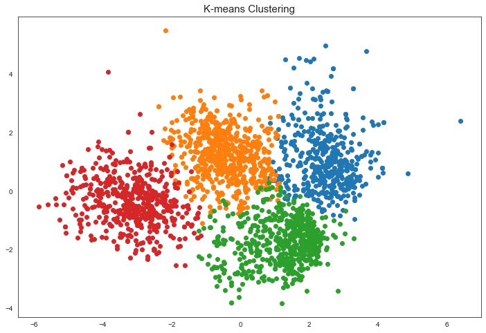

```python
fig, ax = plt.subplots(figsize=(12,8))

# define the model
KM_model = KMeans(n_clusters=4)
# fit the model
KM_model.fit(X)
# assign a cluster to each example
yhat_KM = KM_model.predict(X)
# retrieve unique clusters
clusters = unique(yhat_KM)

plt.title('K-means Clustering', fontsize=15)

# create scatter plot for samples from each cluster
for cluster in clusters:
    # get row indexes for samples with this cluster
    row_ix = where(yhat_KM == cluster)
    # create scatter of these samples
    plt.scatter(X[row_ix, 0], X[row_ix, 1])
# show the plot
plt.show()
```

```python
#Adding the Clusters feature to the orignal dataframe.
data["Clusters_KM"]= yhat_KM
data_copy["Clusters_KM"]= yhat_KM
```

Though K-means gives a decent segregation of data points, clear demarcations in the cluster are not found.

# Agglomerative Clustering

Agglomerative clustering involves grouping data points till a desired number of clusters is achieved.

It one of hierarchical clustering methods Hierarchical clustering, [(wikipedia)](https://en.wikipedia.org/wiki/Hierarchical_clustering)..

It is implemented via the Agglomerative Clustering class and the main configuration to tune is the “n_clusters” set, an estimate of the number of clusters in the data, e.g. 2.

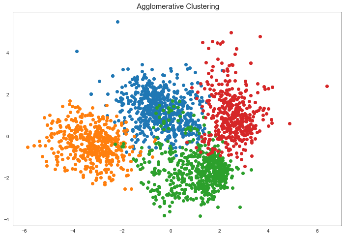

```python
fig, ax = plt.subplots(figsize=(12,8))

# define the model
model = AgglomerativeClustering(n_clusters=4)
# fit model and predict clusters
yhat = model.fit_predict(X)
# retrieve unique clusters
clusters = unique(yhat)

plt.title(' Agglomerative Clustering', fontsize=15)

# create scatter plot for samples from each cluster
for cluster in clusters:
    # get row indexes for samples with this cluster
    row_ix = where(yhat == cluster)
    # create scatter of these samples
    plt.scatter(X[row_ix, 0], X[row_ix, 1])
# show the plot
plt.show()
```

The results of Agglomerative Clustering are very similar to K-Means Clustering. But clustering of middle two groups is better in K-means clustering

# BIRCH

### BRICH or Balanced Iterative Reducing and Clustering using Hierarchies

BIRCH Clustering involves constructing a tree structure from which cluster centroids are extracted.

BIRCH incrementally and dynamically clusters incoming multi-dimensional metric data points to try to produce the best quality clustering with the available resources (i. e., available memory and time constraints).[Reference](https://dl.acm.org/doi/10.1145/235968.233324/)

It is implemented via the Birch class and the main configuration to tune is the “threshold” and “n_clusters” hyper parameters, the latter of which provides an estimate of the number of clusters.

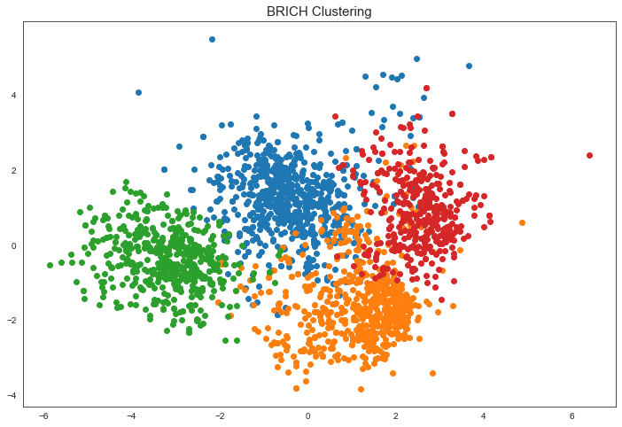

```python
fig, ax = plt.subplots(figsize=(12,8))

# define the model
model = Birch(threshold=0.01, n_clusters=4)
# fit the model
model.fit(X)
# assign a cluster to each example
yhat = model.predict(X)
# retrieve unique clusters
clusters = unique(yhat)

plt.title('BRICH Clustering', fontsize=15)

# create scatter plot for samples from each cluster
for cluster in clusters:
    # get row indexes for samples with this cluster
    row_ix = where(yhat == cluster)
    # create scatter of these samples
    plt.scatter(X[row_ix, 0], X[row_ix, 1])
# show the plot
plt.show()
```

The results of BRICH Clustering are very similar to Agglomerative Clustering

# Gaussian Mixture Model

A Gaussian mixture model summarizes a multivariate probability density function with a mixture of Gaussian probability distributions as its name suggests.

Mixture model, [(wikipedia)](https://en.wikipedia.org/wiki/Mixture_model)..  
It is implemented via the Gaussian Mixture class and the main configuration to tune is the “n_clusters” hyper parameter used to specify the estimated number of clusters in the data.

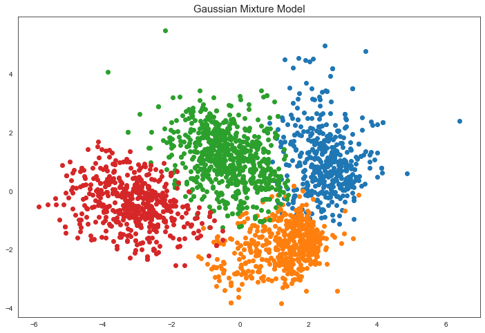

```python
fig, ax = plt.subplots(figsize=(12,8))

# define the model
GMM_model = GaussianMixture(n_components=4, random_state=1)
#Randomstate 2432 for PCA5 and 1 for PCA4
# fit the model
GMM_model.fit(X)
# assign a cluster to each example
yhat_GMM = GMM_model.predict(X)
# retrieve unique clusters
clusters = unique(yhat_GMM)

plt.title('Gaussian Mixture Model', fontsize=15)

# create scatter plot for samples from each cluster
for cluster in clusters:
    # get row indexes for samples with this cluster
    row_ix = where(yhat_GMM == cluster)
    # create scatter of these samples
    plt.scatter(X[row_ix, 0], X[row_ix, 1])
# show the plot
plt.show()
```

The results of Gaussian Mixture Model looks similar to K-Means Clustering.

# Comparing Clustering models with 4 and 5 Principle Components

[figure not shown]

Not much difference is observed when the Principle components are 4 or 5. We will Clustering with 4 Principle components and pick K-Means clustering model.

## **Extracting Cluster Characteristics**

As in supervised learning, un-supervised learning models do not have a target variable to evaluate the performance of our model. In this section we will understand the nature of our clusters using EDA.

```python
data_copy  = data_copy.sort_values(by=['Clusters_KM'])
data_copy["Clusters_KM"].replace({0: 'Cluster-0',1: 'Cluster-1',2: 'Cluster-2',3: 'Cluster-3'}, inplace=True)
```

# Distribution of data points between clusters

```python
color_list=["tan","maroon", "gold","grey"]
```

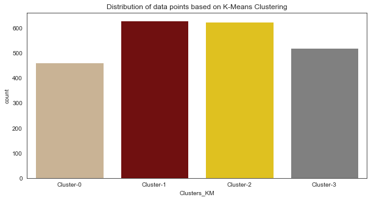

```python
fig, ax1 = plt.subplots(figsize=(10,5))
sns.countplot(x=data_copy["Clusters_KM"], palette=color_list, ax=ax1)
ax1.set_title("Distribution of data points based on K-Means Clustering");
```

We can see a fair distribution of data points between the clusters

# Income vs Spending scatter plot based on K-Means Clusters

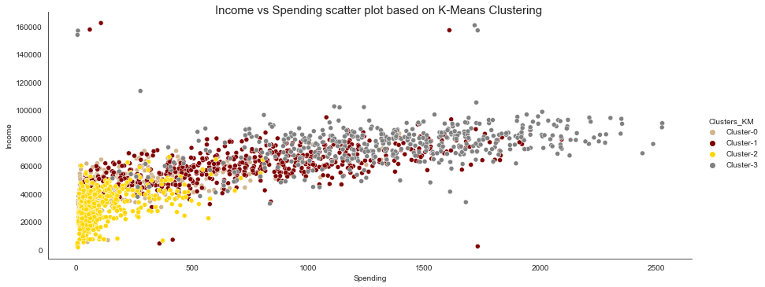

```python
g0 = sns.pairplot(data_copy, x_vars=["Spending"], y_vars=["Income"],
             hue= "Clusters_KM", palette=color_list, height=5, aspect=2.5/1);
g0.fig.suptitle("Income vs Spending scatter plot based on K-Means Clustering", y=1, fontsize=15);
```

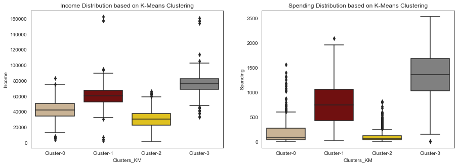

```python
fig, (ax1, ax2) = plt.subplots(1,2, figsize=(15,5))

sns.boxplot(x= "Clusters_KM", y='Income', data=data_copy, palette=color_list, ax=ax1)
ax1.set_title("Income Distribution based on K-Means Clustering")

sns.boxplot(x= "Clusters_KM", y='Spending', data=data_copy, palette=color_list, ax=ax2)
ax2.set_title("Spending Distribution based on K-Means Clustering");
```

**Based on the above Income vs spending scatter plot we can identify 4 cluster as follows:**

Cluster 0: Average Income, Low Spending  
Cluster 1: Average Income, High Spending  
Cluster 2: Low Income, Low Spending  
Cluster 3: High Income, High Spending

# Family Size, Age

```python
family = pd.DataFrame(data_copy.groupby(["Clusters_KM"]).agg({'Family_Size': ['min', 'max', 'mean'],'Children': ['min', 'max', 'mean']})).round(0)
family.index.names = ['']
```

```python
family
```

|  | Family_Size min | Family_Size max | Family_Size mean | Children min | Children max | Children mean |
| --- | --- | --- | --- | --- | --- | --- |
| Cluster-0 | 2 | 5 | 4.0 | 1 | 3 | 2.0 |
| Cluster-1 | 2 | 5 | 3.0 | 0 | 3 | 1.0 |
| Cluster-2 | 1 | 4 | 2.0 | 0 | 2 | 1.0 |
| Cluster-3 | 1 | 3 | 2.0 | 0 | 1 | 0.0 |

```
A look at family size and number of Children in the family
```

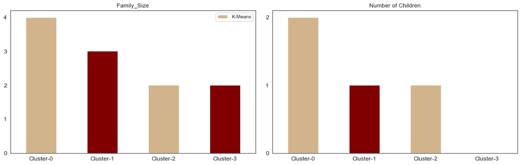

```python
print(color.BOLD+color.BLUE  +"A look at family size and number of Children in the family"+ color.END)

fig, (ax1, ax2) = plt.subplots(1,2, figsize=(15,5))

labels = ['Cluster-0', 'Cluster-1', 'Cluster-2', 'Cluster-3']

family.iloc[:,2].plot(ax=ax1, kind='bar', title ="Family_Size", color=['tan','maroon'],legend=True, fontsize=12).set_xticklabels(labels, rotation=0)
ax1.legend(["K-Means", "GMM"]);
ax1.set_yticklabels(['0','','1','','2','','3','','4'])

family.iloc[:,5].plot(ax=ax2, kind='bar', title ="Number of Children", color=['tan','maroon'],legend=False, fontsize=12).set_xticklabels(labels, rotation=0)
ax2.set_yticklabels(['0','','','','1','','','','2'])

fig.tight_layout(pad=2)

plt.show()
```

```python
#family
#pd.DataFrame(data_copy.groupby("Clusters_KM")['Age'].mean()).join(data_copy.groupby("Clusters_GMM")['Age'].mean(), lsuffix='_KM', rsuffix='_GMM').round(0)
```

```python
kid_KM=pd.DataFrame(data_copy.groupby(['Clusters_KM','Kidhome'])['Kidhome'].count().T.unstack())
teen_KM=pd.DataFrame(data_copy.groupby(['Clusters_KM','Teenhome'])['Teenhome'].count().T.unstack())
relation_KM=pd.DataFrame(data_copy.groupby(['Clusters_KM','Relation_status'])['Relation_status'].count().T.unstack())
kid_KM.index.names = ['']
teen_KM.index.names = ['']
relation_KM.index.names = ['']
```

```python
members = pd.DataFrame(kid_KM).join(teen_KM,lsuffix='_Kids', rsuffix='_Teens')
members = pd.DataFrame(members).join(relation_KM, rsuffix='_relation')
members
```

|  | 0_Kids | 1_Kids | 0_Teens | 1_Teens | 0 | 1 |
| --- | --- | --- | --- | --- | --- | --- |
| Cluster-0 | 38 | 424 | 15 | 447 | 142 | 320 |
| Cluster-1 | 587 | 44 | 40 | 591 | 196 | 435 |
| Cluster-2 | 154 | 473 | 592 | 35 | 243 | 384 |
| Cluster-3 | 514 | 6 | 511 | 9 | 215 | 305 |

```
Who are in the family
```

[figure not shown]

```python
print(color.BOLD+color.BLUE  +"Who are in the family"+ color.END)

fig, ((ax1, ax2),(ax3, ax4)) = plt.subplots(2,2, figsize=(12,10))

labels = ['Cluster-0', 'Cluster-1', 'Cluster-2', 'Cluster-3']

members.iloc[:,[0,1]].plot(ax=ax1, kind='bar', title ="Is there a Kid at home", color=['tan','maroon'],legend=True, fontsize=12).set_xticklabels(labels, rotation=0)
ax1.legend(["No Kids", "Kids"])
ax1.set_yticklabels(['0','','','','','1']);

members.iloc[:,[2,3]].plot(ax=ax2, kind='bar', title ="Is there a teen at home", color=['tan','maroon'],legend=True, fontsize=12).set_xticklabels(labels, rotation=0)
ax2.legend(["No Teens", "Teens"])
ax2.set_yticklabels(['0','','','','','1']);

members.iloc[:,[2,3]].plot(ax=ax3, kind='bar', title ="Couples or Single", color=['tan','maroon'],legend=True, fontsize=12).set_xticklabels(labels, rotation=0)
ax3.legend(["Single","Couples"])
ax3.set_yticklabels(['0','','','','','1']);

sns.boxplot(x= "Clusters_KM", y='Age', data=data_copy, palette=color_list, ax=ax4)
ax4.set_title("Age Distribution based on K-Means Clustering")

#ax4.axis('off')
fig.tight_layout(pad=2)

plt.show()
```

# Spending in various categories

```python
def sum_by_cluster(list_cols):
    return pd.DataFrame(data_copy.groupby(["Clusters_KM"])[list_cols].sum())
```

```python
list_cols = [ 'MntWines', 'MntFruits', 'MntMeatProducts', 'MntFishProducts', 'MntSweetProducts', 'MntGoldProds']
```

```python
purchases_clusters = sum_by_cluster(list_cols).reset_index().drop('Clusters_KM', axis=1).T
```

```python
purchases_clusters
```

|  | 0 | 1 | 2 | 3 |
| --- | --- | --- | --- | --- |
| MntWines | 55265 | 283817 | 22840 | 318894 |
| MntFruits | 2576 | 19605 | 4526 | 32210 |
| MntMeatProducts | 19404 | 99151 | 18094 | 237319 |
| MntFishProducts | 4021 | 25947 | 7027 | 47062 |
| MntSweetProducts | 3005 | 19867 | 4627 | 33122 |
| MntGoldProds | 10284 | 37765 | 12164 | 38396 |

```
Total spending on Wines, Fruits, MeatProducts, FishProducts, SweetProducts, GoldProds based on clusters
```

[figure not shown]

```python
print(color.BOLD+color.BLUE  +"Total spending on Wines, Fruits, MeatProducts, FishProducts, SweetProducts, GoldProds based on clusters"+ color.END)

labels = ['Wines', 'Fruits', 'Meat', 'Fish', 'Sweet', 'Gold']
color_list2=["maroon", "gold","grey","salmon","tan","olive"]
fig, (ax1, ax2, ax3, ax4) = plt.subplots(4,1, figsize=(12,16))

purchases_clusters.iloc[:,0].plot(ax=ax1, kind='bar', title ="Family_Size",legend=False, fontsize=12, color=color_list2).set_xticklabels(labels, rotation=0)
purchases_clusters.iloc[:,1].plot(ax=ax2, kind='bar', title ="Family_Size",legend=False, fontsize=12, color=color_list2).set_xticklabels(labels, rotation=0)
purchases_clusters.iloc[:,2].plot(ax=ax3, kind='bar', title ="Family_Size",legend=False, fontsize=12, color=color_list2).set_xticklabels(labels, rotation=0)
purchases_clusters.iloc[:,3].plot(ax=ax4, kind='bar', title ="Family_Size",legend=False, fontsize=12, color=color_list2).set_xticklabels(labels, rotation=0)

fig.tight_layout(pad=2)

plt.show()
```

**Based spending on Wines, Fruits, Meat Products, Fish Products, Sweet Products, Gold Prods we identify 4 cluster as follows:**

Cluster 0: Spends mostly on Wine and at times on meat  
Cluster 1: Spends mostly on Wine and at times on meat  
Cluster 2: Spends mostly on Wine, Meat, Gold and fish  
Cluster 3: Spends mostly on Wine and Meat

Cluster 0: Spending- Wines High, Meat Products Average, Fruits Very Low  
Cluster 1: Spending- Wines Very High, Meat Products High, Fruits Average  
Cluster 2: Spending- Wines Average, Meat Products Average, Fruits very Low  
Cluster 3: Spending- Wines Very High, Meat Products Very High, Fruits Average

# Customer behavior: Promotions, Complains & Registration

```python
deals_KM=pd.DataFrame(data_copy.groupby(['Clusters_KM'])[['NumDealsPurchases','NumTotalPurchases','Days_Registered','Recency']].mean().round(0))

deals_KM.index.names = ['']
```

```
Customer response towards promotions for all clusters
```

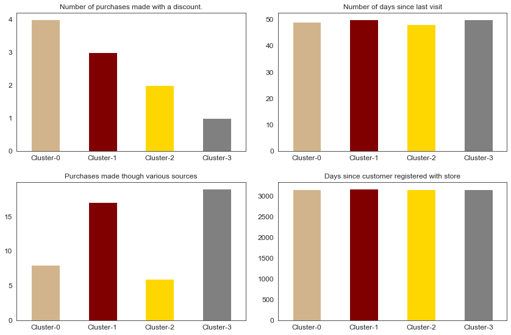

```python
print(color.BOLD+color.BLUE  +"Customer response towards promotions for all clusters"+ color.END)

fig, ((ax1, ax2), (ax3, ax4)) = plt.subplots(2,2, figsize=(12,8))

labels = ['Cluster-0', 'Cluster-1', 'Cluster-2', 'Cluster-3']

deals_KM.iloc[:,0].plot(ax=ax1, kind='bar', title ="Number of purchases made with a discount.", color=color_list,legend=False, fontsize=12).set_xticklabels(labels, rotation=0)
ax1.set_yticklabels(['0','','1','','2','','3','','4'])
deals_KM.iloc[:,1].plot(ax=ax3, kind='bar', title ="Purchases made though various sources", color=color_list,legend=False, fontsize=12).set_xticklabels(labels, rotation=0)
ax3.set_yticklabels(['0','','5','','10','','15','','20'])
deals_KM.iloc[:,2].plot(ax=ax4, kind='bar', title ="Days since customer registered with store", color=color_list,legend=False, fontsize=12).set_xticklabels(labels, rotation=0)
deals_KM.iloc[:,3].plot(ax=ax2, kind='bar', title ="Number of days since last visit", color=color_list,legend=False, fontsize=12).set_xticklabels(labels, rotation=0)


fig.tight_layout(pad=2)

plt.show()
```

**Based spending on customer behavior we identify 4 cluster as follows:**

Cluster 0: On average 4 purchases with promotions, On average 8 purchases from various sources  
Cluster 1: On average 3 purchases with promotions, On average 17 purchases from various sources  
Cluster 2: On average 2 purchases with promotions, On average 6 purchases from various sources  
Cluster 3: On average 1 purchases with promotions, On average 19 purchases from various sources

```python
PromoAccepted_KM=pd.DataFrame(data_copy.groupby(['Clusters_KM','NumPromoAccepted'])['NumPromoAccepted'].sum().T.unstack())
Response_KM=pd.DataFrame(data_copy.groupby(['Clusters_KM','Response'])['Response'].count().T.unstack())
Complain_KM=pd.DataFrame(data_copy.groupby(['Clusters_KM','Complain'])['Complain'].count().T.unstack())

PromoAccepted_KM.index.names = ['']
Response_KM.index.names = ['']
Complain_KM.index.names = ['']
```

```
Response to promotions and complaint status
```

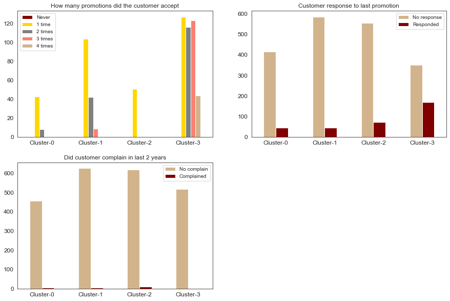

```python
print(color.BOLD+color.BLUE  +"Response to promotions and complaint status"+ color.END)

fig, ((ax1, ax2),(ax3,ax4)) = plt.subplots(2,2, figsize=(15,10))

labels = ['Cluster-0', 'Cluster-1', 'Cluster-2', 'Cluster-3']

PromoAccepted_KM.plot(ax=ax1, kind='bar', title ="How many promotions did the customer accept", color=color_list2,legend=True, fontsize=12).set_xticklabels(labels, rotation=0)
ax1.legend(["Never", "1 time", "2 times", "3 times", "4 times"]);

Response_KM.plot(ax=ax2, kind='bar', title ="Customer response to last promotion", color=['tan','maroon'],legend=True, fontsize=12).set_xticklabels(labels, rotation=0)
ax2.legend(["No response", "Responded"]);

Complain_KM.plot(ax=ax3, kind='bar', title ="Did customer complain in last 2 years", color=['tan','maroon'],legend=True, fontsize=12).set_xticklabels(labels, rotation=0)
ax3.legend(["No complain", "Complained"]);

ax4.axis('off');
```

**Based spending on Response to promotions and complaint status we identify 4 cluster as follows:**

Cluster 0: Accepted offer once or at most twice, Moderate response to last campaign, almost nill complaints in last two years  
Cluster 1: Accepted offer once or at most twice and thrice, Moderate response to last campaign, almost nill complaints in last two years  
Cluster 2: Accepted offer once, Moderate response to last campaign, Few complained in last two years  
Cluster 3: Accepted offer in almost all, High response to last campaign

## **Customer Profiling**

Now that we have formed the clusters and looked at their profile, purchasing habits and behavior, let us see what are the characteristics of each cluster.  
From these characteristics we will get an idea on who is our star customer and which customers need attention.

**Cluster 0**

This cluster consists of a customers around 55 years of age.  
Earning about 40000(Moderate Income), from a household of 4 to 5 members in the Family.  
These customers have a partner and 1 to 3 kids or teenagers in the family.  
These are Low spending customers who spend mostly on Wine and occasionally on meat and very less on Fruits.  
These customers made about 10 purchases from various sources and about half of them with discount.  
Accepted offer once or at most twice, Moderate response to last campaign and almost nill complaints in last two years.

**Cluster 1**

This cluster consists of a customers around 55 years of age.  
Earning about 60000(Moderate Income), from a household of 3 members in the Family.  
These customers have a partner and at least 1 teenager and no Kids in the family.  
These are HIgh spending customers who spend mostly on Wine and meat.  
These customers made about 20 purchases from various sources and less than 20% with discount.  
Accepted offer at most thrice, Moderate response to last campaign and almost nill complaints in last two years.

## **Conclusion**

In this project, I performed unsupervised clustering for Customer Segmentation. I have used PCA for dimensionality reduction, build clusters using K-Means, Agglomerative, BRICH and GMM clustering. Based on the plots generated from clustering models I selected K-Means Clustering. I have finalized 4 clusters for the given dataset. Generated characteristics of each cluster such as demographic, purchasing habits and behavior. These results can further be used to conduct marketing campaigns to generated more revenue.

[References1!..](https://machinelearningmastery.com/clustering-algorithms-with-python/)  
[References2!..](https://www.kaggle.com/karnikakapoor/customer-segmentation-clustering)  
[References3!..](https://www.revechat.com/blog/types-of-customers/)